# Writing Rules for Cleaning Tower Data

Written by Emma Vahle. February 2020.

# Importing Packages and Loading Data

This section imports packages that will be used to group data, perform functions, and plot. The last part of the code imports the data from Tower B.

```python
import numpy as np
import pandas as pd
import os
import matplotlib.pyplot as plt
import re
import seaborn as sn
from data_ingest import read_csv # import home built csv reader
from sklearn.metrics import confusion_matrix, classification_report

# Importing data
df = read_csv('/clean_TowerB_sample2.csv')
# convert the times stamps so they are truly times and
# replace the index with the time so the data is treated as time series
#df.index=pd.to_datetime(df['X'], format='%m/%d/%y %H:%M')
df.dtypes

# inplace tells pandas to just remove the columns
# without it we would need something like df = df.drop()
df.drop(columns=['Unnamed: 0'], inplace = True)
```

# Rule 1: Windspeed

## Writing the Rule as a Function

This code defines a function for Rule 1 that files through the columns of data, selects all of the speed average columns, and creates a new column that returns 'True' if the average speed value is outside the range of 0 to 90 and returns 'False' if the data is inside the range.

```python
def rule_1_flag(df):
    for col in df.columns:
        if re.match('SPD_.*_AVG', col) is not None:
            df['FLAG_SPD_' + str(col.split('_')[1]) + '_' + str(col.split('_')[2]) +
               '_AVG'] = (df[[col]]<0) & (df[[col]]>=90)
```

Now we will call the function and apply it on our Tower B data. Once it has been called, we can look at the data and see that new flag columns have been added for each average speed column.

```python
rule_1_flag(df)
```

## Confusion Matrix

This takes all of the flag columns produced from Rule 1 as well as all of the Erroneous Data columns and puts them together in a new data frame, called 'stackdf', that can be used to compute one confustion matrix for the entire windspeed flag.

```python
FLAGCOL = [col for col in df.columns if re.match('FLAG_SPD.*_AVG', col) is not None]
ERRONEOUS = [col for col in df.columns if re.match('SPD.*_ERRONEOUSDATA', col) is not None]
errordf = df[ERRONEOUS+FLAGCOL]
errordf = errordf.rename(columns={name: '_'.join(['ERRONEOUSDATA']+name.split("_")[:-1])  for name in ERRONEOUS})
errordf = errordf.rename(columns={name: '_'.join(name.split("_")[:-1])  for name in FLAGCOL})
errordf.head()
errordf['id'] = errordf.index
stackdf = pd.wide_to_long(errordf, stubnames=['FLAG_SPD','ERRONEOUSDATA_SPD'],
                          i='id',j='tower', sep = "_", suffix="(\d+_\w+)")
```

This code computes the confusion matrix for the windspeed flag. Because there are no 'True' flag values for the windspeed flag in this data set, the confustion matrix only has one number in it. This means that there was no data flagged for a windspeed outside of the range.

```python
confusion_matrix = pd.crosstab(stackdf['FLAG_SPD'], stackdf['ERRONEOUSDATA_SPD'], rownames=['Actual'],
                               colnames=['Predicted'])
print (confusion_matrix)
```

```
Predicted  False
Actual
False       8352
```

# Rule 2: Flatlining

## Writing the Rule as a Function

```python
def rule_2_flag(df):
    for col in [col for col in df.columns if re.match('SPD_.*_AVG', col)]:
        df['FLATLINE_' + str(col.split('_')[1]) + '_' + str(col.split('_')[2])] \
        = df[col].rolling('50min').apply(lambda x: min(abs(x-x[-1])), raw = True)<0.1
```

Now we will call the function and apply it on our Tower B data. Once it has been called, we can look at the data and see that new flag columns have been added for each average speed column.

```python
rule_2_flag(df)
```

## Confusion Matrix

The confusion matrix is computed the same as it was before by stacking the flag columns in order to compute a single confusion matrix for Flatlining.

```python
FLAGCOL = [col for col in df.columns if re.match('FLATLINE*', col) is not None]
ERRONEOUS = [col for col in df.columns if re.match('SPD.*_ERRONEOUSDATA', col) is not None]
errordf = df[ERRONEOUS+FLAGCOL]
errordf = errordf.rename(columns={name: '_'.join(['ERRONEOUSDATA']+name.split("_")[:-1])  for name in ERRONEOUS})
errordf.head()
errordf['id'] = errordf.index
stackdf = pd.wide_to_long(errordf, stubnames=['FLATLINE','ERRONEOUSDATA_SPD'],
                          i='id',j='tower', sep = "_", suffix="(\d+_\w+)")
```

```python
confusion_matrix = pd.crosstab(stackdf['FLATLINE'], stackdf['ERRONEOUSDATA_SPD'], rownames=['Actual'],
                               colnames=['Predicted'])
print (confusion_matrix)
```

```
Predicted  False
Actual
True        8352
```

# Rule 3: Wind Vane Direction

For a certain time, if the average wind direction maximum absolute difference is greater than 45$^\circ$ and any average wind speed is greater than 3$\frac{\text{m}}{\text{s}}$, it will be flagged for wond vane direction agreement and considered bad data.

This code rolls through the 10 previous entries in a column and takes the maximum absolute difference between any of those 10 entries. It then checks to see if this difference is greater than 45$^\circ$ and if any speed is greater than 3$\frac{\text{m}}{\text{s}}$. The statement inside df.apply() states that "raw = True" which has to do with a warning message about updates to df.apply() and this using this statement will keep the function of df.apply() the same even after updates have happened.

```python
def rule_3_flag(df):
    SPDCOLS = [col for col in df.columns if re.match('SPD.*_AVG', col) is not None]
    SPDdf = df[SPDCOLS]>3
    for col in [col for col in df.columns if re.match('DIR_.*_AVG', col)]:
        df['FLAG_VANE_DIR_' + str(col.split('_')[1]) + '_' + str(col.split('_')[2])] \
        = df[col].rolling('100min').apply(lambda x: max(abs(x-x[-1])), raw = True)>45 \
        * SPDdf.any(axis = 'columns')
```

Now we will call the function and apply it on our Tower B data. Once it has been called, we can look at the data and see that new flag columns have been added for each average vane direction column.

```python
rule_3_flag(df)
```

## Confusion Matrix

The confusion matrix is computed the same as it was before by stacking the flag columns in order to compute a single confusion matrix for Wind Vane Direction.

```python
FLAGCOL = [col for col in df.columns if re.match('FLAG_VANE_DIR.*', col) is not None]
ERRONEOUS = [col for col in df.columns if re.match('DIR.*_ERRONEOUSDATA', col) is not None]
errordf = df[ERRONEOUS+FLAGCOL]
errordf = errordf.rename(columns={name: '_'.join(['ERRONEOUSDATA']+name.split("_")[:-1])  for name in ERRONEOUS})
errordf.head()
errordf['id'] = errordf.index
stackdf = pd.wide_to_long(errordf, stubnames=['FLAG_VANE_DIR','ERRONEOUSDATA_DIR'],
                          i='id',j='tower', sep = "_", suffix="(\d+_\w+)")
```

```python
confusion_matrix = pd.crosstab(stackdf['FLAG_VANE_DIR'], stackdf['ERRONEOUSDATA_DIR'], rownames=['Actual'],
                               colnames=['Predicted'])
print (confusion_matrix)
```

```
Predicted  False  True
Actual
False        990    882
True          83    133
```

# Rule 4: Tower Shading

For a point when the ratio of average windspeeds at the same height is at a maximum or a minimum, the speed will be flagged when the average vane direction is $\pm$30$^\circ$ from the average vane direction at that point.

This code runs through the average speed columns and then takes the ratio between columns that have the same height. It then computes the index of the maximum ratio between the two columns. This index is then used to find the vane direction angle at that same time. The speed column is then flagged at the times when the average vane diection is within $\pm$30$^\circ$ of the angle found.

```python
def rule_4_flag(df):
    SPDAVG = [col for col in df.columns if re.match('SPD_.*_AVG', col) is not None]
    DIRCOLS = [col for col in df.columns if re.match('DIR_.*_AVG', col)]
    for col1 in SPDAVG:
        df['SHADEFLAG_' + str(col1.split('_')[1]) + '_' + str(col1.split('_')[2])] = False
        for col2 in SPDAVG:
            if col1 != col2 and col1.split('_')[1] == col2.split('_')[1]:
                row = (df[col2] / df[col1]).idxmax()
                df['MEAN_DIR'] = df[DIRCOLS].mean(axis = 1)
                angle = df['MEAN_DIR'][row]
                df['SHADEFLAG_' + str(col1.split('_')[1]) + '_' + str(col1.split('_')[2])] = abs(df['MEAN_DIR']-angle)<30
```

Now we will call the function and apply it on our Tower B data. Once it has been called, we can look at the data and see that new flag columns have been added for each average speed column.

```python
rule_4_flag(df)
```

## Confusion Matrix

The confusion matrix is computed the same as it was before by stacking the flag columns in order to compute a single confusion matrix for Tower Shading.

```python
FLAGCOL = [col for col in df.columns if re.match('SHADEFLAG.*', col) is not None]
ERRONEOUS = [col for col in df.columns if re.match('SPD.*_TOWERSHADING', col) is not None]
errordf = df[ERRONEOUS+FLAGCOL]
errordf = errordf.rename(columns={name: '_'.join(['TOWERSHADING']+name.split("_")[:-1])  for name in ERRONEOUS})
errordf.head()
errordf['id'] = errordf.index
stackdf = pd.wide_to_long(errordf, stubnames=['SHADEFLAG','TOWERSHADING_SPD'],
                          i='id',j='tower', sep = "_", suffix="(\d+_\w+)")
```

```python
confusion_matrix = pd.crosstab(stackdf['SHADEFLAG'], stackdf['TOWERSHADING_SPD'], rownames=['Actual'],
                               colnames=['Predicted'])
print (confusion_matrix)
```

```
Predicted  False  True
Actual
False       5205    434
True        2645     68
```

# Plotting

There is still some more work that needs to be done on the visualization of all of these flags. This will be something that I work on in the next month along with evaluating how well the rules work.

```
array([<matplotlib.axes._subplots.AxesSubplot object at 0x000001D7310A32C8>,
      dtype=object)
```

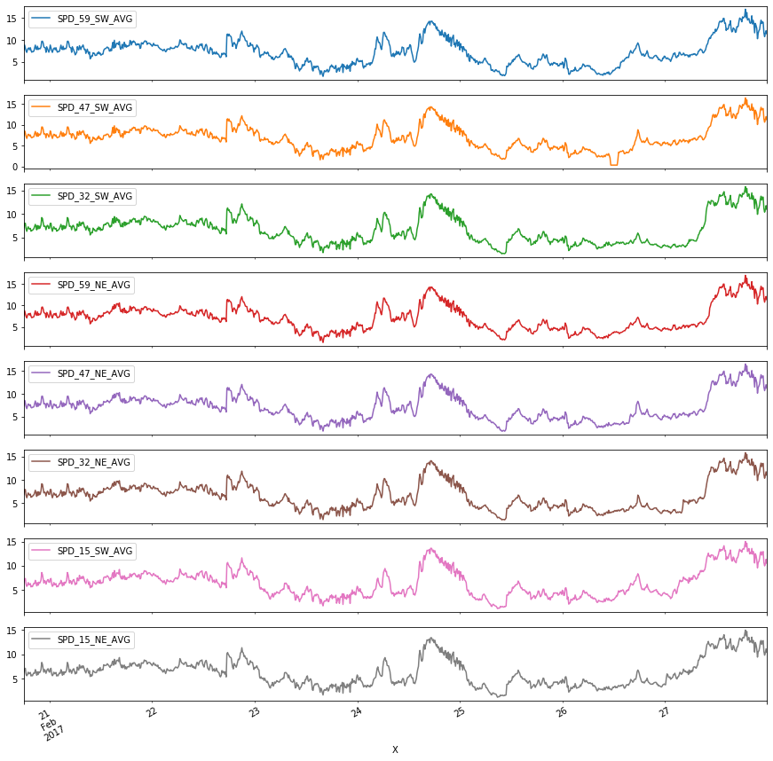

```python
# Averavge Wind Speed
df.plot(y=[col for col in df.columns if re.match('SPD_.*_AVG', col) is not None], figsize=(15,16), subplots=True)
```

```
array([<matplotlib.axes._subplots.AxesSubplot object at 0x000001D73162C488>,
      dtype=object)
```

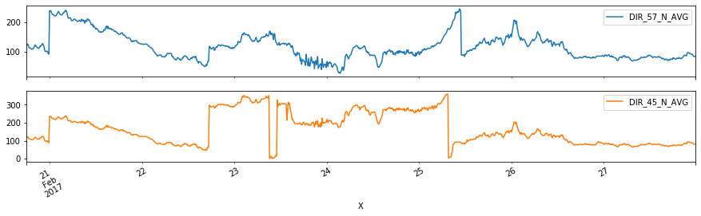

```python
# Vane Direction
df.plot(y=[col for col in df.columns if re.match('DIR_.*_AVG', col) is not None], figsize=(15,4), subplots=True)
```

# Data Frame with New Flag Columns

```python
df
```

| X | SPD_59_SW_AVG | SPD_59_SW_MAX | SPD_59_SW_MIN | SPD_59_SW_SD | SPD_59_SW_ICING | SPD_59_SW_UNHEATED | SPD_59_SW_LOWQUALITY | SPD_59_SW_SENSORFAILURE | SPD_59_SW_TOWERSHADING | SPD_59_SW_ERRONEOUSDATA | ... | FLAG_VANE_DIR_45_N | SHADEFLAG_59_SW | MEAN_DIR | SHADEFLAG_47_SW | SHADEFLAG_32_SW | SHADEFLAG_59_NE | SHADEFLAG_47_NE | SHADEFLAG_32_NE | SHADEFLAG_15_SW | SHADEFLAG_15_NE |
| --- | --- | --- | --- | --- | --- | --- | --- | --- | --- | --- | --- | --- | --- | --- | --- | --- | --- | --- | --- | --- | --- |
| 2017-02-20 18:00:00 | 7.757189 | 9.9125 | 6.0875 | 0.701505 | False | False | False | False | False | False | ... | False | True | 124.577757 | True | False | False | False | False | False | False |
| 2017-02-20 18:10:00 | 8.831020 | 10.6775 | 6.0875 | 0.950054 | False | False | False | False | False | False | ... | False | True | 122.512893 | True | False | False | False | False | False | False |
| 2017-02-20 18:20:00 | 8.132345 | 10.2950 | 6.0875 | 0.871182 | False | False | False | False | False | False | ... | False | True | 125.197938 | True | False | False | False | False | False | False |
| 2017-02-20 18:30:00 | 7.525241 | 9.1475 | 4.5575 | 0.834233 | False | False | False | False | False | False | ... | False | True | 119.337660 | True | False | False | True | False | False | False |
| 2017-02-20 18:40:00 | 7.147025 | 9.1475 | 4.9400 | 0.798890 | False | False | False | False | False | False | ... | False | True | 113.375557 | True | False | False | True | False | True | False |
| ... | ... | ... | ... | ... | ... | ... | ... | ... | ... | ... | ... | ... | ... | ... | ... | ... | ... | ... | ... | ... | ... |
| 2017-02-27 23:10:00 | 11.642701 | 14.8850 | 8.3825 | 1.232033 | False | False | False | False | False | False | ... | False | False | 87.368455 | False | True | True | True | False | True | True |
| 2017-02-27 23:20:00 | 10.754689 | 12.5900 | 8.3825 | 0.950054 | False | False | False | False | False | False | ... | False | False | 83.703401 | False | True | True | True | False | True | True |
| 2017-02-27 23:30:00 | 11.521066 | 14.5025 | 9.1475 | 0.909738 | False | False | False | False | False | False | ... | False | False | 83.021899 | False | True | True | True | False | True | True |
| 2017-02-27 23:40:00 | 12.102848 | 14.8850 | 9.5300 | 0.871182 | False | False | False | False | False | False | ... | False | False | 83.475568 | False | True | True | True | False | True | True |
| 2017-02-27 23:50:00 | 11.415725 | 13.7375 | 9.1475 | 0.798890 | False | False | False | False | False | False | ... | False | False | 84.159543 | False | True | True | True | False | True | True |

1044 rows × 195 columns